# Diagnostic accuracy of ADI-R/ADOS-2 in a naturalistic high-risk ASD sample aged 6-25

Supplementary Materials - Revised version

Ariane Cartigny, Corentin J. Gosling, Georges Chatzis, Ophélia Godin, Ariel Frajerman, Elise Humeau, Paola Atzori, Sara Ramos Pereira, Pierre Ellul, Stéphanie Antoun, Chema Sahnoun Derbel, Elodie Zante, Julien Pottelette, Natalia Robert, Virginie Pomies, Gabrielle Chesnoy, Delphine Weill, Romain Coutelle, Mario Speranza, Anouck Amestoy, the FACE-ASD (FondaMental Advanced Centers of Expertise for Autism Spectrum Disorder) Groups, Sylvain Moutier, Marion Leboyer, Samuele Cortese, Richard Delorme

septembre 14, 2026

# S1. STARD checklist completed / Supplement 1

# S2. Sample

## S2.1 Inclusion flowchart (Figure 1)

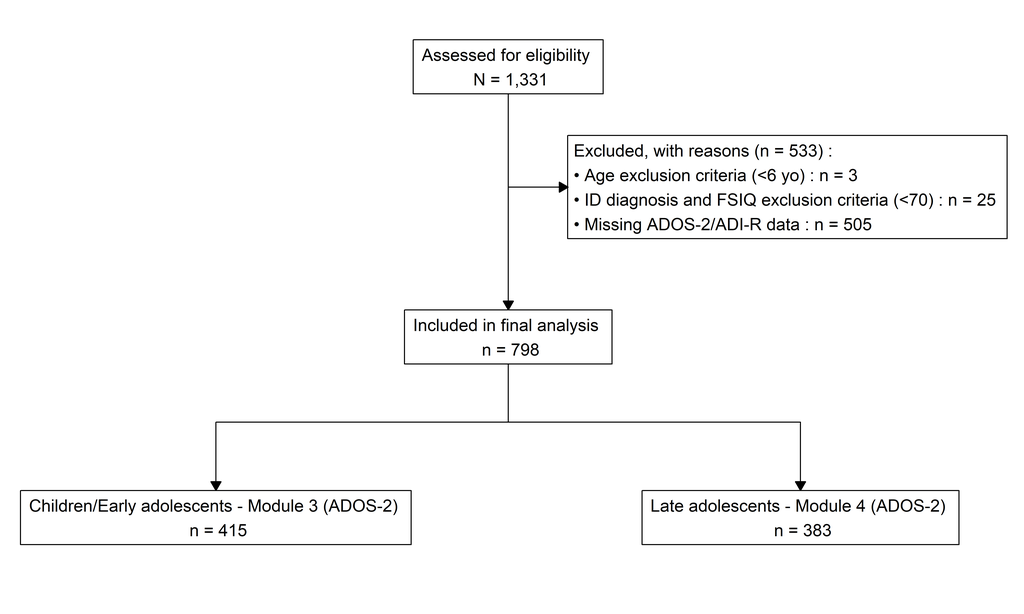

## S2.2 Excluded/Included sample characteristics for main analysis

Table S1. Excluded/Included Sample Characteristics for Main Analysis

|  | Excluded (N=505) | Included (N=798) | P-value - Effect Size |
| --- | --- | --- | --- |
| Age (years) |  |  |  |
| Mean (SD) | 17 (5.2) | 15 (5.2) | < .001 |
| Median [Q1, Q3] | 17 [13, 21] | 15 [11, 19] | d = 0.30 |
| Sex |  |  |  |
| Female | 205 (40.6%) | 231 (28.9%) | < .001 |
| Male | 300 (59.4%) | 567 (71.1%) | OR = 1.68 |
| FSIQ |  |  |  |
| Mean (SD) | 110 (17) | 110 (16) | 0.572 |
| Median [Q1, Q3] | 110 [95, 120] | 110 [96, 120] | d = 0.04 |
| Missing | 120 (23.8%) | 85 (10.7%) |  |
| Autism Spectrum Disorder - ASD |  |  |  |
| ASD | 432 (85.5%) | 689 (86.3%) | 0.747 |
| no ASD | 73 (14.5%) | 109 (13.7%) | OR = 0.94 |

```
##    Min. 1st Qu.  Median    Mean 3rd Qu.    Max.     NAs
##    70.5    95.0   107.0   106.9   118.0   158.0     205
```

The proxy measure showed a very high correlation with the full FSIQ scores in participants where both were available (r =0.93, p =0), supporting its validity.

## S2.3 Age distribution

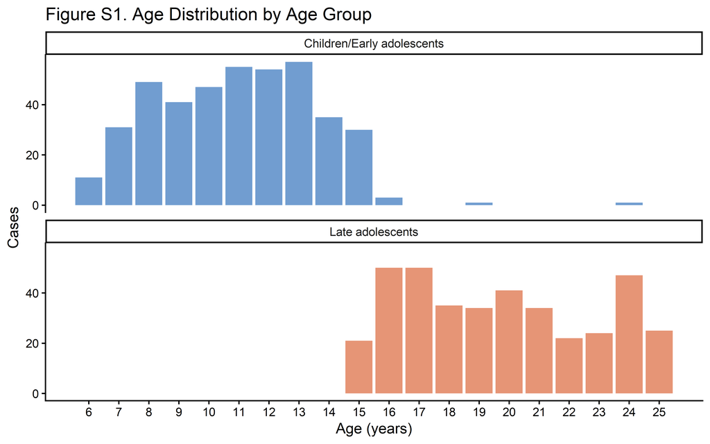

## S2.4 Demographics

### S2.4.1 Main sample characteristics by age group (Table 1)

Table 1. Summary of Main Clinical Characteristics of the Individuals Included in the Study

|  | Children/Early adolescents ASD (N=336) | Children/Early adolescents no ASD (N=79) | Late adolescents ASD (N=353) | Late adolescents no ASD (N=30) |
| --- | --- | --- | --- | --- |
| Age (years) |  |  |  |  |
| Mean (SD) | 11.0 (2.65) | 10.9 (2.43) | 19.8 (3.08) | 19.5 (3.17) |
| Median [Min, Max] | 11.0 [6.00, 24.0] | 11.0 [6.00, 16.0] | 20.0 [15.0, 25.0] | 19.5 [15.0, 25.0] |
| Sex |  |  |  |  |
| Female | 63 (18.8%) | 24 (30.4%) | 136 (38.5%) | 8 (26.7%) |
| Male | 273 (81.3%) | 55 (69.6%) | 217 (61.5%) | 22 (73.3%) |
| FSIQ |  |  |  |  |
| Mean (SD) | 105 (15.8) | 102 (14.2) | 110 (16.7) | 98.7 (13.1) |
| Median [Min, Max] | 104 [71.0, 149] | 102 [75.0, 144] | 110 [73.0, 158] | 99.0 [75.0, 123] |
| Missing | 32 (9.5%) | 7 (8.9%) | 39 (11.0%) | 7 (23.3%) |
| VABS - Total |  |  |  |  |
| Mean (SD) | 60.4 (24.3) | 75.4 (24.8) | 55.8 (25.2) | 50.0 (20.4) |
| Median [Min, Max] | 60.0 [20.0, 124] | 76.5 [21.0, 132] | 56.0 [20.0, 141] | 53.5 [20.0, 95.0] |
| Missing | 100 (29.8%) | 25 (31.6%) | 195 (55.2%) | 16 (53.3%) |
| ADOS-2 - Total |  |  |  |  |
| Mean (SD) | 12.3 (4.84) | 7.75 (4.57) | 10.8 (4.24) | 6.33 (4.69) |
| Median [Min, Max] | 12.5 [0, 26.0] | 7.00 [0, 21.0] | 11.0 [1.00, 24.0] | 5.00 [1.00, 20.0] |
| ADOS-2 - Total (Module 4 revised algorithm) |  |  |  |  |
| Mean (SD) | 12.3 (4.84) | 7.75 (4.57) | 13.9 (5.46) | 8.53 (6.25) |
| Median [Min, Max] | 12.5 [0, 26.0] | 7.00 [0, 21.0] | 14.0 [2.00, 28.0] | 6.50 [1.00, 26.0] |
| ADOS-2 - CSS |  |  |  |  |
| Mean (SD) | 6.99 (2.30) | 4.47 (2.62) | 7.11 (2.43) | 4.40 (2.92) |
| Median [Min, Max] | 7.50 [1.00, 10.0] | 4.00 [1.00, 10.0] | 8.00 [1.00, 10.0] | 3.00 [1.00, 10.0] |
| ADI-R - Total A |  |  |  |  |
| Mean (SD) | 13.4 (6.04) | 8.48 (5.63) | 13.4 (6.29) | 8.53 (5.88) |
| Median [Min, Max] | 13.0 [0, 29.0] | 7.00 [0, 26.0] | 13.0 [0, 27.0] | 7.00 [0, 24.0] |
| Missing | 2 (0.6%) | 0 (0%) | 0 (0%) | 0 (0%) |
| ADI-R - Total B |  |  |  |  |
| Mean (SD) | 9.67 (4.59) | 6.25 (3.89) | 9.16 (5.01) | 6.20 (4.47) |
| Median [Min, Max] | 9.50 [0, 23.0] | 5.00 [0, 19.0] | 9.00 [0, 24.0] | 5.50 [0, 18.0] |
| Missing | 4 (1.2%) | 0 (0%) | 3 (0.8%) | 0 (0%) |
| ADI-R - Total C |  |  |  |  |
| Mean (SD) | 5.30 (2.38) | 3.48 (2.57) | 4.69 (2.74) | 2.07 (1.62) |
| Median [Min, Max] | 5.00 [0, 13.0] | 3.00 [0, 12.0] | 5.00 [0, 25.0] | 2.00 [0, 6.00] |
| Missing | 4 (1.2%) | 0 (0%) | 2 (0.6%) | 0 (0%) |
| Other psychiatric or neurodevelopmental condition |  |  |  |  |
| Any | 240 (71.4%) | 59 (74.7%) | 270 (76.5%) | 16 (53.3%) |
| None | 60 (17.9%) | 12 (15.2%) | 49 (13.9%) | 11 (36.7%) |
| Missing | 36 (10.7%) | 8 (10.1%) | 34 (9.6%) | 3 (10.0%) |
| Ongoing psychiatric treatment |  |  |  |  |
| At least one treatment | 82 (24.4%) | 19 (24.1%) | 75 (21.2%) | 1 (3.3%) |
| No treatment | 205 (61.0%) | 49 (62.0%) | 216 (61.2%) | 24 (80.0%) |
| Missing | 49 (14.6%) | 11 (13.9%) | 62 (17.6%) | 5 (16.7%) |

Note: Values are mean (SD) for continuous variables and n (%) for categorical variables. Participants are stratified by age group - children/early adolescents assessed with ADOS-2 Module 3, and late adolescents assessed with Module 4 - and by final consensus diagnosis. ADI-R scores correspond to domain A (reciprocal social interaction), domain B (communication and language), and domain C (restricted and repetitive behaviors). ADOS-2 total scores are reported for both the original and the revised (Hus and Lord) Module 4 algorithms. The Vineland-II Adaptive Behavior Composite (VABS-2 - Total) is reported as a standard score. ADI-R = Autism Diagnostic Interview-Revised; ADOS-2 = Autism Diagnostic Observation Schedule, Second Edition; ASD = autism spectrum disorder; CSS = calibrated severity score; FSIQ = full-scale IQ; SD = standard deviation.  
a The revised Module 4 algorithm was not applicable to children/early adolescents, who were assessed with Module 3.

### S2.4.2 ADOS-2 CSS age-group comparison

```
## # A tibble: 2 × 7
##   modsaisi     N Moyenne    SD Mediane    Q1    Q3
##      <dbl> <int>   <dbl> <dbl>   <dbl> <dbl> <dbl>
## 1        3   336    6.99  2.30     7.5     6     9
## 2        4   353    7.11  2.43     8       6     9
```

```
##
##  Shapiro-Wilk normality test
##
## data:  dat_CSS$ADOS_CSS
## W = 0.91539, p-value < 2.2e-16
```

```
##
##  Wilcoxon rank sum test with continuity correction
##
## data:  ADOS_CSS by modsaisi
## W = 56319, p-value = 0.2482
## alternative hypothesis: true location shift is not equal to 0
```

The ADOS-2 Calibrated Severity Score did not differ significantly between age groups with ASD (Wilcoxon-Mann-Whitney test, p = 0.248). Children/early adolescents showed a mean score of 6.99 (SD = 2.3; Median = 7.5, IQR: 6–9), whereas late adolescents had a mean of 7.11 (SD = 2.43; Median = 8, IQR: 6–9). No notable difference in symptom severity was therefore observed across age groups.

### S2.4.3 Psychiatric and neurodevelopmental condition

Table S3. Co-occurring Psychiatric and Neurodevelopmental Conditions by Age Group and Final Diagnosis

|  | Children/Early adolescents ASD (N=336) | Children/Early adolescents no ASD (N=79) | Late adolescents ASD (N=353) | Late adolescents no ASD (N=30) |
| --- | --- | --- | --- | --- |
| Other psychiatric or neurodevelopmental condition |  |  |  |  |
| Any | 240 (71.4%) | 59 (74.7%) | 270 (76.5%) | 16 (53.3%) |
| None | 60 (17.9%) | 12 (15.2%) | 49 (13.9%) | 11 (36.7%) |
| Missing | 36 (10.7%) | 8 (10.1%) | 34 (9.6%) | 3 (10.0%) |
| Anxiety Disorder |  |  |  |  |
| Yes | 99 (29.5%) | 26 (32.9%) | 174 (49.3%) | 8 (26.7%) |
| No | 188 (56.0%) | 43 (54.4%) | 76 (21.5%) | 7 (23.3%) |
| Missing | 49 (14.6%) | 10 (12.7%) | 103 (29.2%) | 15 (50.0%) |
| Attention deficit hyperactivity disorder - ADHD |  |  |  |  |
| Yes | 138 (41.1%) | 31 (39.2%) | 53 (15.0%) | 4 (13.3%) |
| No | 141 (42.0%) | 36 (45.6%) | 181 (51.3%) | 10 (33.3%) |
| Missing | 57 (17.0%) | 12 (15.2%) | 119 (33.7%) | 16 (53.3%) |
| Oppositional Defiant Disorder and Conduct Disorder |  |  |  |  |
| Yes | 15 (4.5%) | 10 (12.7%) | 7 (2.0%) | 1 (3.3%) |
| No | 267 (79.5%) | 57 (72.2%) | 235 (66.6%) | 14 (46.7%) |
| Missing | 54 (16.1%) | 12 (15.2%) | 111 (31.4%) | 15 (50.0%) |
| Chronic Tic Disorder |  |  |  |  |
| Yes | 21 (6.3%) | 1 (1.3%) | 11 (3.1%) | 0 (0%) |
| No | 263 (78.3%) | 68 (86.1%) | 239 (67.7%) | 14 (46.7%) |
| Missing | 52 (15.5%) | 10 (12.7%) | 103 (29.2%) | 16 (53.3%) |
| Depressive disorders |  |  |  |  |
| Yes | 18 (5.4%) | 4 (5.1%) | 110 (31.2%) | 5 (16.7%) |
| No | 269 (80.1%) | 65 (82.3%) | 138 (39.1%) | 10 (33.3%) |
| Missing | 49 (14.6%) | 10 (12.7%) | 105 (29.7%) | 15 (50.0%) |
| Bipolar and related disorders |  |  |  |  |
| Yes | 6 (1.8%) | 1 (1.3%) | 25 (7.1%) | 3 (10.0%) |
| No | 279 (83.0%) | 67 (84.8%) | 216 (61.2%) | 12 (40.0%) |
| Missing | 51 (15.2%) | 11 (13.9%) | 112 (31.7%) | 15 (50.0%) |
| Schizophrenia spectrum and Psychotic symptoms |  |  |  |  |
| Yes | 4 (1.2%) | 0 (0%) | 13 (3.7%) | 3 (10.0%) |
| No | 279 (83.0%) | 67 (84.8%) | 235 (66.6%) | 12 (40.0%) |
| Missing | 53 (15.8%) | 12 (15.2%) | 105 (29.7%) | 15 (50.0%) |
| Substance Use |  |  |  |  |
| Yes | 1 (0.3%) | 0 (0%) | 14 (4.0%) | 4 (13.3%) |
| No | 287 (85.4%) | 69 (87.3%) | 237 (67.1%) | 11 (36.7%) |
| Missing | 48 (14.3%) | 10 (12.7%) | 102 (28.9%) | 15 (50.0%) |
| Sphincter Control Disorder |  |  |  |  |
| Yes | 19 (5.7%) | 5 (6.3%) | 11 (3.1%) | 1 (3.3%) |
| No | 267 (79.5%) | 64 (81.0%) | 243 (68.8%) | 14 (46.7%) |
| Missing | 50 (14.9%) | 10 (12.7%) | 99 (28.0%) | 15 (50.0%) |
| Eating Disorder |  |  |  |  |
| Yes | 11 (3.3%) | 7 (8.9%) | 24 (6.8%) | 0 (0%) |
| No | 278 (82.7%) | 62 (78.5%) | 228 (64.6%) | 14 (46.7%) |
| Missing | 47 (14.0%) | 10 (12.7%) | 101 (28.6%) | 16 (53.3%) |
| Developmental Coordination Disorder |  |  |  |  |
| Yes | 29 (8.6%) | 10 (12.7%) | 20 (5.7%) | 1 (3.3%) |
| No | 99 (29.5%) | 33 (41.8%) | 118 (33.4%) | 4 (13.3%) |
| Missing | 208 (61.9%) | 36 (45.6%) | 215 (60.9%) | 25 (83.3%) |
| Language disorders |  |  |  |  |
| Yes | 86 (25.6%) | 20 (25.3%) | 27 (7.6%) | 5 (16.7%) |
| No | 48 (14.3%) | 24 (30.4%) | 114 (32.3%) | 2 (6.7%) |
| Missing | 202 (60.1%) | 35 (44.3%) | 212 (60.1%) | 23 (76.7%) |
| Sleep-Wake disorders |  |  |  |  |
| Yes | 60 (17.9%) | 10 (12.7%) | 90 (25.5%) | 1 (3.3%) |
| No | 132 (39.3%) | 34 (43.0%) | 160 (45.3%) | 20 (66.7%) |
| Missing | 144 (42.9%) | 35 (44.3%) | 103 (29.2%) | 9 (30.0%) |
| Self-harming and suicidal behaviors |  |  |  |  |
| Yes | 34 (10.1%) | 9 (11.4%) | 84 (23.8%) | 3 (10.0%) |
| No | 153 (45.5%) | 36 (45.6%) | 174 (49.3%) | 20 (66.7%) |
| Missing | 149 (44.3%) | 34 (43.0%) | 95 (26.9%) | 7 (23.3%) |
| Learning disorders |  |  |  |  |
| Yes | 84 (25.0%) | 16 (20.3%) | 87 (24.6%) | 7 (23.3%) |
| No | 77 (22.9%) | 24 (30.4%) | 159 (45.0%) | 9 (30.0%) |
| Missing | 175 (52.1%) | 39 (49.4%) | 107 (30.3%) | 14 (46.7%) |

Note: Values are n (%). Co-occurring conditions were identified by experienced psychiatrists using a structured clinical interview according to DSM-5 criteria — the K-SADS-PL for children/early adolescents and the DIGS for late adolescents. Conditions are not mutually exclusive; participants could meet criteria for more than one. ADHD = attention-deficit/hyperactivity disorder; ADOS-2 = Autism Diagnostic Observation Schedule, Second Edition; ASD = autism spectrum disorder; DIGS = Diagnostic Interview for Genetic Studies; DSM-5 = Diagnostic and Statistical Manual of Mental Disorders, Fifth Edition; K-SADS-PL = Schedule for Affective Disorders and Schizophrenia for School-Age Children–Present and Lifetime Version.

### S2.4.4 Ongoing psychiatric treatments by therapeutic class

Table S4. Ongoing Psychiatric Treatments by Therapeutic Class

|  | Children/Early adolescents ASD (N=336) | Children/Early adolescents no ASD (N=79) | Late adolescents ASD (N=353) | Late adolescents no ASD (N=30) |
| --- | --- | --- | --- | --- |
| Ongoing psychiatric treatment |  |  |  |  |
| At least one treatment | 82 (24.4%) | 19 (24.1%) | 75 (21.2%) | 1 (3.3%) |
| No treatment | 205 (61.0%) | 49 (62.0%) | 216 (61.2%) | 24 (80.0%) |
| Missing | 49 (14.6%) | 11 (13.9%) | 62 (17.6%) | 5 (16.7%) |
| Number of treatment category |  |  |  |  |
| 1 | 47 (14.0%) | 13 (16.5%) | 41 (11.6%) | 1 (3.3%) |
| 2 to 5 | 34 (10.1%) | 6 (7.6%) | 33 (9.3%) | 0 (0%) |
| None | 206 (61.3%) | 49 (62.0%) | 217 (61.5%) | 24 (80.0%) |
| Missing | 49 (14.6%) | 11 (13.9%) | 62 (17.6%) | 5 (16.7%) |
| Methylphenidate |  |  |  |  |
| Yes | 54 (16.1%) | 10 (12.7%) | 10 (2.8%) | 0 (0%) |
| No | 233 (69.3%) | 58 (73.4%) | 281 (79.6%) | 25 (83.3%) |
| Missing | 49 (14.6%) | 11 (13.9%) | 62 (17.6%) | 5 (16.7%) |
| Melatonin |  |  |  |  |
| Yes | 27 (8.0%) | 5 (6.3%) | 10 (2.8%) | 0 (0%) |
| No | 260 (77.4%) | 63 (79.7%) | 281 (79.6%) | 25 (83.3%) |
| Missing | 49 (14.6%) | 11 (13.9%) | 62 (17.6%) | 5 (16.7%) |
| Antipsychotic |  |  |  |  |
| Yes | 16 (4.8%) | 9 (11.4%) | 27 (7.6%) | 1 (3.3%) |
| No | 271 (80.7%) | 59 (74.7%) | 264 (74.8%) | 24 (80.0%) |
| Missing | 49 (14.6%) | 11 (13.9%) | 62 (17.6%) | 5 (16.7%) |
| Antidepressant |  |  |  |  |
| Yes | 11 (3.3%) | 2 (2.5%) | 44 (12.5%) | 0 (0%) |
| No | 276 (82.1%) | 66 (83.5%) | 247 (70.0%) | 25 (83.3%) |
| Missing | 49 (14.6%) | 11 (13.9%) | 62 (17.6%) | 5 (16.7%) |
| Anxiolytics and Benzodiazepin |  |  |  |  |
| Yes | 2 (0.6%) | 0 (0%) | 17 (4.8%) | 0 (0%) |
| No | 285 (84.8%) | 68 (86.1%) | 274 (77.6%) | 25 (83.3%) |
| Missing | 49 (14.6%) | 11 (13.9%) | 62 (17.6%) | 5 (16.7%) |

Note: Values are n (%).

### S2.4.5 Children/early adolescents group

#### S2.4.5.1 Main group characteristics

Table S5. Summary of Main Clinical Characteristics of the Children/Early Adolescents Group

|  | ASD (N=336) | no ASD (N=79) | P value / Effect size |
| --- | --- | --- | --- |
| Age (years) |  |  |  |
| Mean (SD) | 11.0 (2.65) | 10.9 (2.43) | 0.772 |
| Median [Min, Max] | 11.0 [6.00, 24.0] | 11.0 [6.00, 16.0] | d = 0.04 |
| Sex |  |  |  |
| Female | 63 (18.8%) | 24 (30.4%) | 0.033 |
| Male | 273 (81.3%) | 55 (69.6%) | OR = 0.53 |
| FSIQ |  |  |  |
| Mean (SD) | 105 (15.8) | 102 (14.2) | 0.307 |
| Median [Min, Max] | 104 [71.0, 149] | 102 [75.0, 144] | d = 0.13 |
| Missing | 32 (9.5%) | 7 (8.9%) |  |
| VABS - Daily life |  |  |  |
| Mean (SD) | 76.3 (23.5) | 84.7 (22.1) | 0.008 |
| Median [Min, Max] | 79.0 [20.0, 143] | 86.0 [34.0, 121] | d = -0.36 |
| Missing | 64 (19.0%) | 11 (13.9%) |  |
| VABS - Communication |  |  |  |
| Mean (SD) | 71.9 (22.6) | 80.0 (21.7) | 0.008 |
| Median [Min, Max] | 73.0 [20.0, 122] | 78.0 [32.0, 132] | d = -0.36 |
| Missing | 64 (19.0%) | 11 (13.9%) |  |
| VABS - Socialization |  |  |  |
| Mean (SD) | 53.3 (26.5) | 69.1 (29.0) | < .001 |
| Median [Min, Max] | 50.0 [14.0, 114] | 70.0 [20.0, 134] | d = -0.58 |
| Missing | 74 (22.0%) | 15 (19.0%) |  |
| VABS - Total |  |  |  |
| Mean (SD) | 60.4 (24.3) | 75.4 (24.8) | < .001 |
| Median [Min, Max] | 60.0 [20.0, 124] | 76.5 [21.0, 132] | d = -0.62 |
| Missing | 100 (29.8%) | 25 (31.6%) |  |
| ADOS-2 - Total |  |  |  |
| Mean (SD) | 12.3 (4.84) | 7.75 (4.57) | < .001 |
| Median [Min, Max] | 12.5 [0, 26.0] | 7.00 [0, 21.0] | d = 0.95 |
| ADOS-2 - CSS |  |  |  |
| Mean (SD) | 6.99 (2.30) | 4.47 (2.62) | < .001 |
| Median [Min, Max] | 7.50 [1.00, 10.0] | 4.00 [1.00, 10.0] | d = 1.07 |
| ADI-R - Total A |  |  |  |
| Mean (SD) | 13.4 (6.04) | 8.48 (5.63) | < .001 |
| Median [Min, Max] | 13.0 [0, 29.0] | 7.00 [0, 26.0] | d = 0.83 |
| Missing | 2 (0.6%) | 0 (0%) |  |
| ADI-R - Total B |  |  |  |
| Mean (SD) | 9.67 (4.59) | 6.25 (3.89) | < .001 |
| Median [Min, Max] | 9.50 [0, 23.0] | 5.00 [0, 19.0] | d = 0.77 |
| Missing | 4 (1.2%) | 0 (0%) |  |
| ADI-R - Total C |  |  |  |
| Mean (SD) | 5.30 (2.38) | 3.48 (2.57) | < .001 |
| Median [Min, Max] | 5.00 [0, 13.0] | 3.00 [0, 12.0] | d = 0.75 |
| Missing | 4 (1.2%) | 0 (0%) |  |
| Other psychiatric or neurodevelopmental condition |  |  |  |
| Any | 240 (71.4%) | 59 (74.7%) | 0.670 |
| None | 60 (17.9%) | 12 (15.2%) | OR = 0.81 |
| Missing | 36 (10.7%) | 8 (10.1%) |  |
| Ongoing psychiatric treatment |  |  |  |
| At least one treatment | 82 (24.4%) | 19 (24.1%) | 1.000 |
| No treatment | 205 (61.0%) | 49 (62.0%) | OR = 1.03 |
| Missing | 49 (14.6%) | 11 (13.9%) |  |

#### S2.4.5.2 Psychiatric and neurodevelopmental conditions

Table S6. Co-occurring Psychiatric and Neurodevelopmental Conditions of the Children/Early Adolescents Group

|  | ASD (N=336) | no ASD (N=79) | P value / Effect size |
| --- | --- | --- | --- |
| Age (years) |  |  |  |
| Mean (SD) | 11.0 (2.65) | 10.9 (2.43) | 0.772 |
| Median [Min, Max] | 11.0 [6.00, 24.0] | 11.0 [6.00, 16.0] | d = 0.04 |
| Sex |  |  |  |
| Female | 63 (18.8%) | 24 (30.4%) | 0.033 |
| Male | 273 (81.3%) | 55 (69.6%) | OR = 0.53 |
| Other psychiatric or neurodevelopmental condition |  |  |  |
| Any | 240 (71.4%) | 59 (74.7%) | 0.670 |
| None | 60 (17.9%) | 12 (15.2%) | OR = 0.81 |
| Missing | 36 (10.7%) | 8 (10.1%) |  |
| Anxiety Disorder |  |  |  |
| Yes | 99 (29.5%) | 26 (32.9%) | 0.721 |
| No | 188 (56.0%) | 43 (54.4%) | OR = 0.87 |
| Missing | 49 (14.6%) | 10 (12.7%) |  |
| Attention deficit hyperactivity disorder - ADHD |  |  |  |
| Yes | 138 (41.1%) | 31 (39.2%) | 0.739 |
| No | 141 (42.0%) | 36 (45.6%) | OR = 1.14 |
| Missing | 57 (17.0%) | 12 (15.2%) |  |
| Oppositional Defiant Disorder and Conduct Disorder |  |  |  |
| Yes | 15 (4.5%) | 10 (12.7%) | 0.013 |
| No | 267 (79.5%) | 57 (72.2%) | OR = 0.32 |
| Missing | 54 (16.1%) | 12 (15.2%) |  |
| Chronic Tic Disorder |  |  |  |
| Yes | 21 (6.3%) | 1 (1.3%) | 0.120 |
| No | 263 (78.3%) | 68 (86.1%) | OR = 5.43 |
| Missing | 52 (15.5%) | 10 (12.7%) |  |
| Depressive disorders |  |  |  |
| Yes | 18 (5.4%) | 4 (5.1%) | 1.000 |
| No | 269 (80.1%) | 65 (82.3%) | OR = 1.09 |
| Missing | 49 (14.6%) | 10 (12.7%) |  |
| Bipolar and related disorders |  |  |  |
| Yes | 6 (1.8%) | 1 (1.3%) | 1.000 |
| No | 279 (83.0%) | 67 (84.8%) | OR = 1.44 |
| Missing | 51 (15.2%) | 11 (13.9%) |  |
| Schizophrenia spectrum and Psychotic symptoms |  |  |  |
| Yes | 4 (1.2%) | 0 (0%) | 0.734 |
| No | 279 (83.0%) | 67 (84.8%) | OR = 2.17 |
| Missing | 53 (15.8%) | 12 (15.2%) |  |
| Substance Use |  |  |  |
| Yes | 1 (0.3%) | 0 (0%) | 1.000 |
| No | 287 (85.4%) | 69 (87.3%) | OR = 0.73 |
| Missing | 48 (14.3%) | 10 (12.7%) |  |
| Sphincter Control Disorder |  |  |  |
| Yes | 19 (5.7%) | 5 (6.3%) | 1.000 |
| No | 267 (79.5%) | 64 (81.0%) | OR = 0.91 |
| Missing | 50 (14.9%) | 10 (12.7%) |  |
| Eating Disorder |  |  |  |
| Yes | 11 (3.3%) | 7 (8.9%) | 0.063 |
| No | 278 (82.7%) | 62 (78.5%) | OR = 0.35 |
| Missing | 47 (14.0%) | 10 (12.7%) |  |
| Developmental Coordination Disorder |  |  |  |
| Yes | 29 (8.6%) | 10 (12.7%) | 1.000 |
| No | 99 (29.5%) | 33 (41.8%) | OR = 0.97 |
| Missing | 208 (61.9%) | 36 (45.6%) |  |
| Language disorders |  |  |  |
| Yes | 86 (25.6%) | 20 (25.3%) | 0.044 |
| No | 48 (14.3%) | 24 (30.4%) | OR = 2.15 |
| Missing | 202 (60.1%) | 35 (44.3%) |  |
| Sleep-Wake disorders |  |  |  |
| Yes | 60 (17.9%) | 10 (12.7%) | 0.351 |
| No | 132 (39.3%) | 34 (43.0%) | OR = 1.55 |
| Missing | 144 (42.9%) | 35 (44.3%) |  |
| Self-harming and suicidal behaviors |  |  |  |
| Yes | 34 (10.1%) | 9 (11.4%) | 0.946 |
| No | 153 (45.5%) | 36 (45.6%) | OR = 0.89 |
| Missing | 149 (44.3%) | 34 (43.0%) |  |
| Learning disorders |  |  |  |
| Yes | 84 (25.0%) | 16 (20.3%) | 0.230 |
| No | 77 (22.9%) | 24 (30.4%) | OR = 1.64 |
| Missing | 175 (52.1%) | 39 (49.4%) |  |

#### S2.4.5.3 Ongoing psychiatric treatments

Table S7. Ongoing Psychiatric Treatments by Therapeutic Class of the Children/Early Adolescents Group

|  | ASD (N=336) | no ASD (N=79) | P value / Effect size |
| --- | --- | --- | --- |
| Age (years) |  |  |  |
| Mean (SD) | 11.0 (2.65) | 10.9 (2.43) | 0.772 |
| Median [Min, Max] | 11.0 [6.00, 24.0] | 11.0 [6.00, 16.0] | d = 0.04 |
| Sex |  |  |  |
| Female | 63 (18.8%) | 24 (30.4%) | 0.033 |
| Male | 273 (81.3%) | 55 (69.6%) | OR = 0.53 |
| Methylphenidate |  |  |  |
| Yes | 54 (16.1%) | 10 (12.7%) | 0.537 |
| No | 233 (69.3%) | 58 (73.4%) | OR = 1.34 |
| Missing | 49 (14.6%) | 11 (13.9%) |  |
| Melatonin |  |  |  |
| Yes | 27 (8.0%) | 5 (6.3%) | 0.767 |
| No | 260 (77.4%) | 63 (79.7%) | OR = 1.31 |
| Missing | 49 (14.6%) | 11 (13.9%) |  |
| Antipsychotic |  |  |  |
| Yes | 16 (4.8%) | 9 (11.4%) | 0.050 |
| No | 271 (80.7%) | 59 (74.7%) | OR = 0.39 |
| Missing | 49 (14.6%) | 11 (13.9%) |  |
| Antidepressant |  |  |  |
| Yes | 11 (3.3%) | 2 (2.5%) | 1.000 |
| No | 276 (82.1%) | 66 (83.5%) | OR = 1.32 |
| Missing | 49 (14.6%) | 11 (13.9%) |  |
| Anxiolytics and Benzodiazepin |  |  |  |
| Yes | 2 (0.6%) | 0 (0%) | 1.000 |
| No | 285 (84.8%) | 68 (86.1%) | OR = 1.20 |
| Missing | 49 (14.6%) | 11 (13.9%) |  |
| Hypnotics and Sedatives |  |  |  |
| Yes | 1 (0.3%) | 0 (0%) | 1.000 |
| No | 286 (85.1%) | 68 (86.1%) | OR = 0.72 |
| Missing | 49 (14.6%) | 11 (13.9%) |  |
| Antiepileptic |  |  |  |
| Yes | 2 (0.6%) | 1 (1.3%) | 1.000 |
| No | 285 (84.8%) | 67 (84.8%) | OR = 0.47 |
| Missing | 49 (14.6%) | 11 (13.9%) |  |
| Lithium |  |  |  |
| Yes | 0 (0%) | 0 (0%) | < .001 |
| No | 287 (85.4%) | 68 (86.1%) | V = Inf |
| Missing | 49 (14.6%) | 11 (13.9%) |  |

Note: Values are n (%).

### S2.4.6 Late adolescents group

#### S2.4.6.1 Main group characteristics

Table S8. Summary of Main Clinical Characteristics of the Late Adolescents Group

|  | ASD (N=353) | no ASD (N=30) | P value / Effect size |
| --- | --- | --- | --- |
| Age (years) |  |  |  |
| Mean (SD) | 19.8 (3.08) | 19.5 (3.17) | 0.690 |
| Median [Min, Max] | 20.0 [15.0, 25.0] | 19.5 [15.0, 25.0] | d = 0.08 |
| Sex |  |  |  |
| Female | 136 (38.5%) | 8 (26.7%) | 0.275 |
| Male | 217 (61.5%) | 22 (73.3%) | OR = 1.72 |
| FSIQ |  |  |  |
| Mean (SD) | 110 (16.7) | 98.7 (13.1) | 0.001 |
| Median [Min, Max] | 110 [73.0, 158] | 99.0 [75.0, 123] | d = 0.70 |
| Missing | 39 (11.0%) | 7 (23.3%) |  |
| VABS - Daily life |  |  |  |
| Mean (SD) | 67.5 (27.0) | 66.6 (25.8) | 0.905 |
| Median [Min, Max] | 74.0 [20.0, 124] | 65.5 [20.0, 117] | d = 0.03 |
| Missing | 192 (54.4%) | 16 (53.3%) |  |
| VABS - Communication |  |  |  |
| Mean (SD) | 65.1 (25.9) | 55.4 (22.9) | 0.179 |
| Median [Min, Max] | 66.0 [18.0, 114] | 56.5 [23.0, 109] | d = 0.38 |
| Missing | 193 (54.7%) | 16 (53.3%) |  |
| VABS - Socialization |  |  |  |
| Mean (SD) | 50.6 (25.6) | 52.1 (20.1) | 0.838 |
| Median [Min, Max] | 50.0 [12.0, 118] | 54.0 [20.0, 78.0] | d = -0.06 |
| Missing | 192 (54.4%) | 16 (53.3%) |  |
| VABS - Total |  |  |  |
| Mean (SD) | 55.8 (25.2) | 50.0 (20.4) | 0.407 |
| Median [Min, Max] | 56.0 [20.0, 141] | 53.5 [20.0, 95.0] | d = 0.23 |
| Missing | 195 (55.2%) | 16 (53.3%) |  |
| ADOS-2 - Total |  |  |  |
| Mean (SD) | 10.8 (4.24) | 6.33 (4.69) | < .001 |
| Median [Min, Max] | 11.0 [1.00, 24.0] | 5.00 [1.00, 20.0] | d = 1.05 |
| ADOS-2 - Total (Module 4 revised algorithm) |  |  |  |
| Mean (SD) | 13.9 (5.46) | 8.53 (6.25) | < .001 |
| Median [Min, Max] | 14.0 [2.00, 28.0] | 6.50 [1.00, 26.0] | d = 0.98 |
| ADOS-2 - CSS |  |  |  |
| Mean (SD) | 7.11 (2.43) | 4.40 (2.92) | < .001 |
| Median [Min, Max] | 8.00 [1.00, 10.0] | 3.00 [1.00, 10.0] | d = 1.10 |
| ADI-R - Total A |  |  |  |
| Mean (SD) | 13.4 (6.29) | 8.53 (5.88) | < .001 |
| Median [Min, Max] | 13.0 [0, 27.0] | 7.00 [0, 24.0] | d = 0.78 |
| ADI-R - Total B |  |  |  |
| Mean (SD) | 9.16 (5.01) | 6.20 (4.47) | 0.002 |
| Median [Min, Max] | 9.00 [0, 24.0] | 5.50 [0, 18.0] | d = 0.60 |
| Missing | 3 (0.8%) | 0 (0%) |  |
| ADI-R - Total C |  |  |  |
| Mean (SD) | 4.69 (2.74) | 2.07 (1.62) | < .001 |
| Median [Min, Max] | 5.00 [0, 25.0] | 2.00 [0, 6.00] | d = 0.98 |
| Missing | 2 (0.6%) | 0 (0%) |  |
| Other psychiatric or neurodevelopmental condition |  |  |  |
| Any | 270 (76.5%) | 16 (53.3%) | 0.002 |
| None | 49 (13.9%) | 11 (36.7%) | OR = 3.79 |
| Missing | 34 (9.6%) | 3 (10.0%) |  |
| Ongoing psychiatric treatment |  |  |  |
| At least one treatment | 75 (21.2%) | 1 (3.3%) | 0.028 |
| No treatment | 216 (61.2%) | 24 (80.0%) | OR = 8.33 |
| Missing | 62 (17.6%) | 5 (16.7%) |  |

#### S2.4.6.2 Psychiatric and neurodevelopmental conditions

Table S9. Co-occurring Psychiatric and Neurodevelopmental Conditions of the Late Adolescents Group

|  | ASD (N=353) | no ASD (N=30) | P value / Effect size |
| --- | --- | --- | --- |
| Age (years) |  |  |  |
| Mean (SD) | 19.8 (3.08) | 19.5 (3.17) | 0.690 |
| Median [Min, Max] | 20.0 [15.0, 25.0] | 19.5 [15.0, 25.0] | d = 0.08 |
| Sex |  |  |  |
| Female | 136 (38.5%) | 8 (26.7%) | 0.275 |
| Male | 217 (61.5%) | 22 (73.3%) | OR = 1.72 |
| Other psychiatric or neurodevelopmental condition |  |  |  |
| Any | 270 (76.5%) | 16 (53.3%) | 0.002 |
| None | 49 (13.9%) | 11 (36.7%) | OR = 3.79 |
| Missing | 34 (9.6%) | 3 (10.0%) |  |
| Anxiety Disorder |  |  |  |
| Yes | 174 (49.3%) | 8 (26.7%) | 0.302 |
| No | 76 (21.5%) | 7 (23.3%) | OR = 2.00 |
| Missing | 103 (29.2%) | 15 (50.0%) |  |
| Attention deficit hyperactivity disorder - ADHD |  |  |  |
| Yes | 53 (15.0%) | 4 (13.3%) | 0.854 |
| No | 181 (51.3%) | 10 (33.3%) | OR = 0.73 |
| Missing | 119 (33.7%) | 16 (53.3%) |  |
| Oppositional Defiant Disorder and Conduct Disorder |  |  |  |
| Yes | 7 (2.0%) | 1 (3.3%) | 0.960 |
| No | 235 (66.6%) | 14 (46.7%) | OR = 0.42 |
| Missing | 111 (31.4%) | 15 (50.0%) |  |
| Chronic Tic Disorder |  |  |  |
| Yes | 11 (3.1%) | 0 (0%) | 0.909 |
| No | 239 (67.7%) | 14 (46.7%) | OR = 1.39 |
| Missing | 103 (29.2%) | 16 (53.3%) |  |
| Depressive disorders |  |  |  |
| Yes | 110 (31.2%) | 5 (16.7%) | 0.570 |
| No | 138 (39.1%) | 10 (33.3%) | OR = 1.59 |
| Missing | 105 (29.7%) | 15 (50.0%) |  |
| Bipolar and related disorders |  |  |  |
| Yes | 25 (7.1%) | 3 (10.0%) | 0.464 |
| No | 216 (61.2%) | 12 (40.0%) | OR = 0.46 |
| Missing | 112 (31.7%) | 15 (50.0%) |  |
| Schizophrenia spectrum and Psychotic symptoms |  |  |  |
| Yes | 13 (3.7%) | 3 (10.0%) | 0.077 |
| No | 235 (66.6%) | 12 (40.0%) | OR = 0.22 |
| Missing | 105 (29.7%) | 15 (50.0%) |  |
| Substance Use |  |  |  |
| Yes | 14 (4.0%) | 4 (13.3%) | 0.009 |
| No | 237 (67.1%) | 11 (36.7%) | OR = 0.16 |
| Missing | 102 (28.9%) | 15 (50.0%) |  |
| Sphincter Control Disorder |  |  |  |
| Yes | 11 (3.1%) | 1 (3.3%) | 1.000 |
| No | 243 (68.8%) | 14 (46.7%) | OR = 0.63 |
| Missing | 99 (28.0%) | 15 (50.0%) |  |
| Eating Disorder |  |  |  |
| Yes | 24 (6.8%) | 0 (0%) | 0.465 |
| No | 228 (64.6%) | 14 (46.7%) | OR = 3.11 |
| Missing | 101 (28.6%) | 16 (53.3%) |  |
| Developmental Coordination Disorder |  |  |  |
| Yes | 20 (5.7%) | 1 (3.3%) | 1.000 |
| No | 118 (33.4%) | 4 (13.3%) | OR = 0.68 |
| Missing | 215 (60.9%) | 25 (83.3%) |  |
| Language disorders |  |  |  |
| Yes | 27 (7.6%) | 5 (16.7%) | 0.005 |
| No | 114 (32.3%) | 2 (6.7%) | OR = 0.09 |
| Missing | 212 (60.1%) | 23 (76.7%) |  |
| Sleep-Wake disorders |  |  |  |
| Yes | 90 (25.5%) | 1 (3.3%) | 0.008 |
| No | 160 (45.3%) | 20 (66.7%) | OR = 11.25 |
| Missing | 103 (29.2%) | 9 (30.0%) |  |
| Self-harming and suicidal behaviors |  |  |  |
| Yes | 84 (23.8%) | 3 (10.0%) | 0.088 |
| No | 174 (49.3%) | 20 (66.7%) | OR = 3.22 |
| Missing | 95 (26.9%) | 7 (23.3%) |  |
| Learning disorders |  |  |  |
| Yes | 87 (24.6%) | 7 (23.3%) | 0.683 |
| No | 159 (45.0%) | 9 (30.0%) | OR = 0.70 |
| Missing | 107 (30.3%) | 14 (46.7%) |  |

#### S2.4.6.3 Ongoing psychiatric treatments

Table S10. Ongoing Psychiatric Treatments by Therapeutic Class the Late Adolescents Group

|  | ASD (N=353) | no ASD (N=30) | P value / Effect size |
| --- | --- | --- | --- |
| Ongoing psychiatric treatment |  |  |  |
| At least one treatment | 75 (21.2%) | 1 (3.3%) | 0.028 |
| No treatment | 216 (61.2%) | 24 (80.0%) | OR = 8.33 |
| Missing | 62 (17.6%) | 5 (16.7%) |  |
| Methylphenidate |  |  |  |
| Yes | 10 (2.8%) | 0 (0%) | 0.729 |
| No | 281 (79.6%) | 25 (83.3%) | OR = 1.90 |
| Missing | 62 (17.6%) | 5 (16.7%) |  |
| Melatonin |  |  |  |
| Yes | 10 (2.8%) | 0 (0%) | 0.729 |
| No | 281 (79.6%) | 25 (83.3%) | OR = 1.90 |
| Missing | 62 (17.6%) | 5 (16.7%) |  |
| Antipsychotic |  |  |  |
| Yes | 27 (7.6%) | 1 (3.3%) | 0.600 |
| No | 264 (74.8%) | 24 (80.0%) | OR = 2.45 |
| Missing | 62 (17.6%) | 5 (16.7%) |  |
| Antidepressant |  |  |  |
| Yes | 44 (12.5%) | 0 (0%) | 0.073 |
| No | 247 (70.0%) | 25 (83.3%) | OR = 9.17 |
| Missing | 62 (17.6%) | 5 (16.7%) |  |
| Anxiolytics and Benzodiazepin |  |  |  |
| Yes | 17 (4.8%) | 0 (0%) | 0.435 |
| No | 274 (77.6%) | 25 (83.3%) | OR = 3.25 |
| Missing | 62 (17.6%) | 5 (16.7%) |  |
| Hypnotics and Sedatives |  |  |  |
| Yes | 0 (0%) | 0 (0%) | < .001 |
| No | 291 (82.4%) | 25 (83.3%) | V = Inf |
| Missing | 62 (17.6%) | 5 (16.7%) |  |
| Antiepileptic |  |  |  |
| Yes | 1 (0.3%) | 0 (0%) | 1.000 |
| No | 290 (82.2%) | 25 (83.3%) | OR = 0.26 |
| Missing | 62 (17.6%) | 5 (16.7%) |  |
| Lithium |  |  |  |
| Yes | 1 (0.3%) | 0 (0%) | 1.000 |
| No | 290 (82.2%) | 25 (83.3%) | OR = 0.26 |
| Missing | 62 (17.6%) | 5 (16.7%) |  |

Note: Values are n (%).

### S2.4.7 Main characteristics by ADOS-2 accuracy tables

#### S2.4.7.1 Children/early adolescents group

Table S11. Main characteristics by ADOS-2 accuracy tables for Children/early adolescents group

|  | ADOS-2 correct ASD (N=301) | ADOS-2 correct no ASD (N=40) | P value / Effect size ASD (N=35) | P value / Effect size no ASD (N=39) |
| --- | --- | --- | --- | --- |
| Age (years) |  |  |  |  |
| Mean (SD) | 10.9 (2.66) | 10.4 (2.34) | 11.1 (2.55) | 11.3 (2.45) |
| Median [Min, Max] | 11.0 [6.00, 24.0] | 11.0 [6.00, 15.0] | 11.0 [6.00, 15.0] | 11.0 [6.00, 16.0] |
| Sex |  |  |  |  |
| Female | 54 (17.9%) | 13 (32.5%) | 9 (25.7%) | 11 (28.2%) |
| Male | 247 (82.1%) | 27 (67.5%) | 26 (74.3%) | 28 (71.8%) |
| FSIQ |  |  |  |  |
| Mean (SD) | 104 (15.8) | 104 (14.5) | 108 (15.6) | 101 (14.1) |
| Median [Min, Max] | 104 [71.0, 149] | 102 [76.0, 144] | 110 [74.0, 144] | 101 [75.0, 129] |
| Missing | 31 (10.3%) | 5 (12.5%) | 1 (2.9%) | 2 (5.1%) |
| VABS - Socialization |  |  |  |  |
| Mean (SD) | 52.3 (26.1) | 72.2 (26.2) | 62.3 (28.9) | 66.2 (31.6) |
| Median [Min, Max] | 50.0 [14.0, 110] | 73.0 [20.0, 121] | 58.0 [20.0, 114] | 69.0 [20.0, 134] |
| Missing | 66 (21.9%) | 9 (22.5%) | 8 (22.9%) | 6 (15.4%) |
| VABS - Total |  |  |  |  |
| Mean (SD) | 59.4 (24.2) | 78.4 (23.3) | 69.0 (23.5) | 72.9 (26.2) |
| Median [Min, Max] | 60.0 [20.0, 121] | 76.0 [27.0, 124] | 69.5 [30.0, 124] | 77.0 [21.0, 132] |
| Missing | 91 (30.2%) | 15 (37.5%) | 9 (25.7%) | 10 (25.6%) |
| ADOS-2 - Total |  |  |  |  |
| Mean (SD) | 13.2 (4.21) | 4.28 (1.92) | 4.40 (1.90) | 11.3 (3.66) |
| Median [Min, Max] | 13.0 [7.00, 26.0] | 5.00 [0, 10.0] | 5.00 [0, 9.00] | 11.0 [7.00, 21.0] |
| ADI-R - Total A |  |  |  |  |
| Mean (SD) | 13.6 (6.07) | 8.00 (5.00) | 12.1 (5.73) | 8.97 (6.24) |
| Median [Min, Max] | 13.0 [0, 29.0] | 6.50 [1.00, 24.0] | 11.0 [1.00, 27.0] | 8.00 [0, 26.0] |
| Missing | 2 (0.7%) | 0 (0%) | 0 (0%) | 0 (0%) |
| ADI-R - Total B |  |  |  |  |
| Mean (SD) | 9.84 (4.61) | 5.80 (3.78) | 8.23 (4.24) | 6.72 (3.99) |
| Median [Min, Max] | 10.0 [0, 23.0] | 5.00 [0, 18.0] | 8.00 [2.00, 18.0] | 6.00 [0, 19.0] |
| Missing | 4 (1.3%) | 0 (0%) | 0 (0%) | 0 (0%) |
| ADI-R - Total C |  |  |  |  |
| Mean (SD) | 5.32 (2.39) | 3.23 (2.53) | 5.20 (2.37) | 3.74 (2.62) |
| Median [Min, Max] | 5.00 [0, 13.0] | 2.50 [0, 9.00] | 5.00 [0, 9.00] | 3.00 [0, 12.0] |
| Missing | 4 (1.3%) | 0 (0%) | 0 (0%) | 0 (0%) |
| Other psychiatric or neurodevelopmental condition |  |  |  |  |
| Any | 215 (71.4%) | 27 (67.5%) | 25 (71.4%) | 32 (82.1%) |
| None | 53 (17.6%) | 7 (17.5%) | 7 (20.0%) | 5 (12.8%) |
| Missing | 33 (11.0%) | 6 (15.0%) | 3 (8.6%) | 2 (5.1%) |
| Ongoing psychiatric treatment |  |  |  |  |
| At least one treatment | 72 (23.9%) | 6 (15.0%) | 10 (28.6%) | 13 (33.3%) |
| No treatment | 185 (61.5%) | 29 (72.5%) | 20 (57.1%) | 20 (51.3%) |
| Missing | 44 (14.6%) | 5 (12.5%) | 5 (14.3%) | 6 (15.4%) |

Note: Values are n (%).

#### S2.4.7.2 Late adolescents group

Table S12. Main characteristics by ADOS-2 accuracy tables for Late adolescents group

|  | ADOS-2 correct ASD (N=284) | ADOS-2 correct no ASD (N=20) | P value / Effect size ASD (N=69) | P value / Effect size no ASD (N=10) |
| --- | --- | --- | --- | --- |
| Age (years) |  |  |  |  |
| Mean (SD) | 19.8 (3.07) | 20.3 (3.18) | 19.8 (3.16) | 18.0 (2.67) |
| Median [Min, Max] | 19.5 [15.0, 25.0] | 20.5 [15.0, 25.0] | 20.0 [15.0, 25.0] | 17.0 [15.0, 23.0] |
| Sex |  |  |  |  |
| Female | 104 (36.6%) | 6 (30.0%) | 32 (46.4%) | 2 (20.0%) |
| Male | 180 (63.4%) | 14 (70.0%) | 37 (53.6%) | 8 (80.0%) |
| FSIQ |  |  |  |  |
| Mean (SD) | 110 (16.8) | 97.2 (13.3) | 112 (16.3) | 101 (13.3) |
| Median [Min, Max] | 109 [73.0, 158] | 96.0 [75.0, 123] | 113 [73.0, 150] | 103 [75.0, 122] |
| Missing | 27 (9.5%) | 7 (35.0%) | 12 (17.4%) | 0 (0%) |
| VABS - Socialization |  |  |  |  |
| Mean (SD) | 49.1 (24.9) | 51.6 (23.0) | 55.9 (27.7) | 52.3 (19.8) |
| Median [Min, Max] | 48.0 [12.0, 118] | 50.0 [20.0, 78.0] | 56.0 [20.0, 104] | 56.0 [20.0, 78.0] |
| Missing | 159 (56.0%) | 15 (75.0%) | 33 (47.8%) | 1 (10.0%) |
| VABS - Total |  |  |  |  |
| Mean (SD) | 54.4 (25.0) | 47.0 (20.6) | 60.5 (25.5) | 51.7 (21.4) |
| Median [Min, Max] | 53.5 [20.0, 141] | 58.0 [20.0, 66.0] | 64.5 [20.0, 107] | 50.0 [31.0, 95.0] |
| Missing | 162 (57.0%) | 15 (75.0%) | 33 (47.8%) | 1 (10.0%) |
| ADOS-2 - Total |  |  |  |  |
| Mean (SD) | 12.3 (3.36) | 3.60 (1.85) | 5.00 (1.76) | 11.8 (3.71) |
| Median [Min, Max] | 12.0 [6.00, 24.0] | 4.00 [1.00, 7.00] | 5.00 [1.00, 11.0] | 11.0 [8.00, 20.0] |
| ADOS-2 - Total (Module 4 revised algorithm) |  |  |  |  |
| Mean (SD) | 15.6 (4.63) | 5.00 (2.90) | 7.17 (2.70) | 15.6 (4.99) |
| Median [Min, Max] | 15.0 [5.00, 28.0] | 4.00 [1.00, 13.0] | 7.00 [2.00, 15.0] | 14.0 [10.0, 26.0] |
| ADI-R - Total A |  |  |  |  |
| Mean (SD) | 13.7 (6.26) | 9.70 (6.51) | 12.1 (6.29) | 6.20 (3.58) |
| Median [Min, Max] | 13.0 [0, 27.0] | 9.00 [0, 24.0] | 11.0 [1.00, 25.0] | 5.00 [2.00, 13.0] |
| ADI-R - Total B |  |  |  |  |
| Mean (SD) | 9.35 (4.98) | 6.50 (4.89) | 8.38 (5.09) | 5.60 (3.63) |
| Median [Min, Max] | 9.00 [0, 23.0] | 5.50 [0, 18.0] | 8.00 [0, 24.0] | 5.50 [0, 11.0] |
| Missing | 2 (0.7%) | 0 (0%) | 1 (1.4%) | 0 (0%) |
| ADI-R - Total C |  |  |  |  |
| Mean (SD) | 4.83 (2.81) | 2.25 (1.86) | 4.09 (2.32) | 1.70 (0.949) |
| Median [Min, Max] | 5.00 [0, 25.0] | 2.00 [0, 6.00] | 4.00 [0, 10.0] | 2.00 [0, 3.00] |
| Missing | 0 (0%) | 0 (0%) | 2 (2.9%) | 0 (0%) |
| Other psychiatric or neurodevelopmental condition |  |  |  |  |
| Any | 219 (77.1%) | 8 (40.0%) | 51 (73.9%) | 8 (80.0%) |
| None | 40 (14.1%) | 10 (50.0%) | 9 (13.0%) | 1 (10.0%) |
| Missing | 25 (8.8%) | 2 (10.0%) | 9 (13.0%) | 1 (10.0%) |
| Ongoing psychiatric treatment |  |  |  |  |
| At least one treatment | 62 (21.8%) | 0 (0%) | 13 (18.8%) | 1 (10.0%) |
| No treatment | 172 (60.6%) | 17 (85.0%) | 44 (63.8%) | 7 (70.0%) |
| Missing | 50 (17.6%) | 3 (15.0%) | 12 (17.4%) | 2 (20.0%) |

Note: Values are n (%).

### S2.4.8 Main characteristics by ADI-R accuracy tables

#### S2.4.8.1 Children/early adolescents group

Table S13. Main characteristics by ADI-R accuracy tables for Children/early adolescents group

|  | ADI-R correct ASD (N=172) | ADI-R correct no ASD (N=65) | P value / Effect size ASD (N=164) | P value / Effect size no ASD (N=14) |
| --- | --- | --- | --- | --- |
| Age (years) |  |  |  |  |
| Mean (SD) | 10.8 (2.72) | 10.9 (2.41) | 11.1 (2.57) | 10.7 (2.58) |
| Median [Min, Max] | 11.0 [6.00, 24.0] | 11.0 [6.00, 16.0] | 11.0 [6.00, 16.0] | 12.0 [6.00, 14.0] |
| Sex |  |  |  |  |
| Female | 24 (14.0%) | 22 (33.8%) | 39 (23.8%) | 2 (14.3%) |
| Male | 148 (86.0%) | 43 (66.2%) | 125 (76.2%) | 12 (85.7%) |
| FSIQ |  |  |  |  |
| Mean (SD) | 103 (16.0) | 103 (14.8) | 107 (15.3) | 97.7 (9.60) |
| Median [Min, Max] | 101 [71.0, 149] | 104 [75.0, 144] | 107 [73.0, 144] | 97.0 [78.0, 117] |
| Missing | 15 (8.7%) | 4 (6.2%) | 17 (10.4%) | 3 (21.4%) |
| VABS - Socialization |  |  |  |  |
| Mean (SD) | 47.7 (24.6) | 71.7 (29.2) | 58.0 (27.2) | 57.8 (26.6) |
| Median [Min, Max] | 43.0 [20.0, 114] | 73.0 [20.0, 134] | 54.0 [14.0, 112] | 68.0 [20.0, 107] |
| Missing | 54 (31.4%) | 13 (20.0%) | 20 (12.2%) | 2 (14.3%) |
| VABS - Total |  |  |  |  |
| Mean (SD) | 55.3 (23.3) | 77.9 (25.0) | 64.8 (24.3) | 65.8 (22.7) |
| Median [Min, Max] | 53.5 [20.0, 124] | 80.0 [21.0, 132] | 65.5 [20.0, 121] | 70.0 [33.0, 110] |
| Missing | 64 (37.2%) | 22 (33.8%) | 36 (22.0%) | 3 (21.4%) |
| ADOS-2 - Total |  |  |  |  |
| Mean (SD) | 12.8 (4.89) | 7.77 (4.35) | 11.7 (4.74) | 7.64 (5.67) |
| Median [Min, Max] | 13.0 [0, 25.0] | 7.00 [0, 21.0] | 12.0 [2.00, 26.0] | 5.00 [0, 18.0] |
| ADI-R - Total A |  |  |  |  |
| Mean (SD) | 17.2 (4.83) | 7.26 (5.00) | 9.54 (4.50) | 14.1 (5.01) |
| Median [Min, Max] | 17.0 [9.00, 29.0] | 6.00 [0, 20.0] | 9.00 [0, 24.0] | 13.0 [10.0, 26.0] |
| Missing | 2 (1.2%) | 0 (0%) | 0 (0%) | 0 (0%) |
| ADI-R - Total B |  |  |  |  |
| Mean (SD) | 12.5 (3.62) | 5.15 (3.01) | 6.73 (3.55) | 11.4 (3.48) |
| Median [Min, Max] | 12.0 [2.00, 23.0] | 4.00 [0, 12.0] | 6.00 [0, 17.0] | 10.0 [8.00, 19.0] |
| Missing | 2 (1.2%) | 0 (0%) | 2 (1.2%) | 0 (0%) |
| ADI-R - Total C |  |  |  |  |
| Mean (SD) | 6.24 (2.11) | 2.92 (2.39) | 4.33 (2.27) | 6.07 (1.69) |
| Median [Min, Max] | 6.00 [1.00, 13.0] | 2.00 [0, 12.0] | 4.00 [0, 10.0] | 6.00 [3.00, 9.00] |
| Missing | 2 (1.2%) | 0 (0%) | 2 (1.2%) | 0 (0%) |
| Other psychiatric or neurodevelopmental condition |  |  |  |  |
| Any | 120 (69.8%) | 50 (76.9%) | 120 (73.2%) | 9 (64.3%) |
| None | 29 (16.9%) | 10 (15.4%) | 31 (18.9%) | 2 (14.3%) |
| Missing | 23 (13.4%) | 5 (7.7%) | 13 (7.9%) | 3 (21.4%) |
| Ongoing psychiatric treatment |  |  |  |  |
| At least one treatment | 38 (22.1%) | 18 (27.7%) | 44 (26.8%) | 1 (7.1%) |
| No treatment | 106 (61.6%) | 37 (56.9%) | 99 (60.4%) | 12 (85.7%) |
| Missing | 28 (16.3%) | 10 (15.4%) | 21 (12.8%) | 1 (7.1%) |

Note: Values are n (%).

#### S2.4.8.2 Late adolescents group

Table S14. Main characteristics by ADI-R accuracy tables for Late adolescents group

|  | ADI-R correct ASD (N=155) | ADI-R correct no ASD (N=26) | P value / Effect size ASD (N=198) | P value / Effect size no ASD (N=4) |
| --- | --- | --- | --- | --- |
| Age (years) |  |  |  |  |
| Mean (SD) | 19.7 (3.01) | 19.6 (3.32) | 19.8 (3.15) | 19.3 (2.22) |
| Median [Min, Max] | 20.0 [15.0, 25.0] | 19.0 [15.0, 25.0] | 19.0 [15.0, 25.0] | 20.0 [16.0, 21.0] |
| Sex |  |  |  |  |
| Female | 46 (29.7%) | 8 (30.8%) | 90 (45.5%) | 0 (0%) |
| Male | 109 (70.3%) | 18 (69.2%) | 108 (54.5%) | 4 (100%) |
| FSIQ |  |  |  |  |
| Mean (SD) | 109 (17.0) | 101 (11.3) | 111 (16.5) | 75.0 (0) |
| Median [Min, Max] | 108 [73.0, 150] | 102 [81.5, 123] | 112 [75.0, 158] | 75.0 [75.0, 75.0] |
| Missing | 15 (9.7%) | 5 (19.2%) | 24 (12.1%) | 2 (50.0%) |
| VABS - Socialization |  |  |  |  |
| Mean (SD) | 39.6 (22.9) | 54.4 (18.9) | 57.2 (25.0) | 22.0 (NA) |
| Median [Min, Max] | 33.0 [12.0, 104] | 56.0 [20.0, 78.0] | 58.0 [20.0, 118] | 22.0 [22.0, 22.0] |
| Missing | 95 (61.3%) | 13 (50.0%) | 97 (49.0%) | 3 (75.0%) |
| VABS - Total |  |  |  |  |
| Mean (SD) | 45.9 (23.5) | 51.1 (20.8) | 61.6 (24.5) | 36.0 (NA) |
| Median [Min, Max] | 44.0 [20.0, 107] | 57.0 [20.0, 95.0] | 64.0 [20.0, 141] | 36.0 [36.0, 36.0] |
| Missing | 96 (61.9%) | 13 (50.0%) | 99 (50.0%) | 3 (75.0%) |
| ADOS-2 - Total |  |  |  |  |
| Mean (SD) | 11.3 (4.04) | 6.54 (4.93) | 10.5 (4.37) | 5.00 (2.58) |
| Median [Min, Max] | 12.0 [2.00, 24.0] | 5.00 [1.00, 20.0] | 10.0 [1.00, 20.0] | 5.00 [2.00, 8.00] |
| ADOS-2 - Total (Module 4 revised algorithm) |  |  |  |  |
| Mean (SD) | 14.4 (5.16) | 8.92 (6.53) | 13.6 (5.66) | 6.00 (3.56) |
| Median [Min, Max] | 15.0 [2.00, 26.0] | 7.00 [1.00, 26.0] | 13.0 [2.00, 28.0] | 5.00 [3.00, 11.0] |
| ADI-R - Total A |  |  |  |  |
| Mean (SD) | 17.4 (4.90) | 7.46 (4.83) | 10.3 (5.44) | 15.5 (8.06) |
| Median [Min, Max] | 18.0 [3.00, 27.0] | 6.50 [0, 17.0] | 10.0 [0, 26.0] | 16.0 [6.00, 24.0] |
| ADI-R - Total B |  |  |  |  |
| Mean (SD) | 12.5 (4.14) | 5.08 (3.45) | 6.56 (3.97) | 13.5 (3.42) |
| Median [Min, Max] | 12.0 [0, 24.0] | 4.00 [0, 12.0] | 6.00 [0, 21.0] | 13.0 [10.0, 18.0] |
| Missing | 2 (1.3%) | 0 (0%) | 1 (0.5%) | 0 (0%) |
| ADI-R - Total C |  |  |  |  |
| Mean (SD) | 5.81 (2.26) | 1.65 (1.23) | 3.82 (2.77) | 4.75 (1.26) |
| Median [Min, Max] | 6.00 [0, 12.0] | 2.00 [0, 4.00] | 4.00 [0, 25.0] | 5.00 [3.00, 6.00] |
| Missing | 1 (0.6%) | 0 (0%) | 1 (0.5%) | 0 (0%) |
| Other psychiatric or neurodevelopmental condition |  |  |  |  |
| Any | 118 (76.1%) | 13 (50.0%) | 152 (76.8%) | 3 (75.0%) |
| None | 25 (16.1%) | 10 (38.5%) | 24 (12.1%) | 1 (25.0%) |
| Missing | 12 (7.7%) | 3 (11.5%) | 22 (11.1%) | 0 (0%) |
| Ongoing psychiatric treatment |  |  |  |  |
| At least one treatment | 28 (18.1%) | 1 (3.8%) | 47 (23.7%) | 0 (0%) |
| No treatment | 104 (67.1%) | 20 (76.9%) | 112 (56.6%) | 4 (100%) |
| Missing | 23 (14.8%) | 5 (19.2%) | 39 (19.7%) | 0 (0%) |

Note: Values are n (%).

# S3. Main analysis

```r
test_metrics = function(x, test, age) {
  res = testCompareR::summariseR(x, dp=3)
  rawres = data.frame(rbind(
    res["acc"][[1]], res["lr"][[1]]
  ))
  rawres[, "Test"] <- test
  rawres[, "Age"] <- age
  rownames(rawres)[rownames(rawres) == "Sensitivity"] <- "Sensitivity"
  rownames(rawres)[rownames(rawres) == "Specificity"] <- "Specificity"
  rownames(rawres)[rownames(rawres) == "NLR"] <- "LR-"
  rownames(rawres)[rownames(rawres) == "PLR"] <- "LR+"
  return(rawres)
}
```

## S3.1 Children / early adolescents group

### S3.1.1 Individual

#### ADI-R (Module 3)

```
##             Estimate    SE Lower.CI Upper.CI  Test                        Age
## Sensitivity   51.190 2.727   45.864   56.492 ADI-R Children/Early adolescents
## Specificity   82.278 4.296   72.532   89.248 ADI-R Children/Early adolescents
## LR+            2.889 0.717    1.815    4.716 ADI-R Children/Early adolescents
## LR-            0.593 0.045    0.520    0.703 ADI-R Children/Early adolescents
```

#### ADOS-2 (Module 3)

```
##             Estimate    SE Lower.CI Upper.CI   Test                        Age
## Sensitivity   89.583 1.667   85.890   92.447 ADOS-2 Children/Early adolescents
## Specificity   50.633 5.625   39.840   61.372 ADOS-2 Children/Early adolescents
## LR+            1.815 0.210    1.480    2.320 ADOS-2 Children/Early adolescents
## LR-            0.206 0.040    0.139    0.300 ADOS-2 Children/Early adolescents
```

### S3.1.2 Combination

#### ADOS-2 + ADI-R (OR) - Module 3

```
##             Estimate    SE Lower.CI Upper.CI
## Sensitivity   94.048 1.291   91.021   96.150
## Specificity   39.241 5.494   29.177   50.230
## LR+            1.548 0.142    1.323    1.892
## LR-            0.152 0.039    0.088    0.246
##                                                 Test                        Age
## Sensitivity ADOS-2 OR ADI-R (sensitivity-maximizing) Children/Early adolescents
## Specificity ADOS-2 OR ADI-R (sensitivity-maximizing) Children/Early adolescents
## LR+         ADOS-2 OR ADI-R (sensitivity-maximizing) Children/Early adolescents
## LR-         ADOS-2 OR ADI-R (sensitivity-maximizing) Children/Early adolescents
```

#### ADOS-2 + ADI-R (AND) - Module 3

```
##             Estimate    SE Lower.CI Upper.CI
## Sensitivity   46.726 2.722   41.456   52.065
## Specificity   93.671 2.739   86.172   97.413
## LR+            7.383 3.224    3.242   16.730
## LR-            0.569 0.033    0.515    0.652
##                                                  Test
## Sensitivity ADOS-2 AND ADI-R (specificity-maximizing)
## Specificity ADOS-2 AND ADI-R (specificity-maximizing)
## LR+         ADOS-2 AND ADI-R (specificity-maximizing)
## LR-         ADOS-2 AND ADI-R (specificity-maximizing)
##                                    Age
## Sensitivity Children/Early adolescents
## Specificity Children/Early adolescents
## LR+         Children/Early adolescents
## LR-         Children/Early adolescents
```

### S3.1.3 Comparison

#### Individual

```
##     test      metric estimate lower_ci upper_ci   p
## 1  ADI-R Sensitivity     51.2     45.9     56.5
## 2 ADOS-2 Sensitivity     89.6     85.9     92.4 ***
## 3  ADI-R Specificity     82.3     72.5     89.2 ***
## 4 ADOS-2 Specificity     50.6     39.8     61.4
## 5  ADI-R         PLR      2.9      1.8      4.7
## 6 ADOS-2         PLR      1.8      1.5      2.3
## 7  ADI-R         NLR      0.6      0.5      0.7 ***
## 8 ADOS-2         NLR      0.2      0.1      0.3
##
## Signif. codes:  0 '***' 0.001 '**' 0.01 '*' 0.05 ' ' 1
```

#### Combination vs ADI-R

```
##        test      metric estimate lower_ci upper_ci   p
## 1     ADI-R Sensitivity     51.2     45.9     56.5
## 2 COMB (OR) Sensitivity     94.0     91.0     96.2 ***
## 3     ADI-R Specificity     82.3     72.5     89.2 ***
## 4 COMB (OR) Specificity     39.2     29.2     50.2
## 5     ADI-R         PLR      2.9      1.8      4.7  **
## 6 COMB (OR)         PLR      1.5      1.3      1.9
## 7     ADI-R         NLR      0.6      0.5      0.7 ***
## 8 COMB (OR)         NLR      0.2      0.1      0.2
##
## Signif. codes:  0 '***' 0.001 '**' 0.01 '*' 0.05 ' ' 1
```

```
##         test      metric estimate lower_ci upper_ci  p
## 1      ADI-R Sensitivity     51.2     45.9     56.5 **
## 2 COMB (AND) Sensitivity     46.7     41.5     52.1
## 3      ADI-R Specificity     82.3     72.5     89.2
## 4 COMB (AND) Specificity     93.7     86.2     97.4  *
## 5      ADI-R         PLR      2.9      1.8      4.7
## 6 COMB (AND)         PLR      7.4      3.2     16.7  *
## 7      ADI-R         NLR      0.6      0.5      0.7
## 8 COMB (AND)         NLR      0.6      0.5      0.7
##
## Signif. codes:  0 '***' 0.001 '**' 0.01 '*' 0.05 ' ' 1
```

#### Combination vs ADOS-2

```
##        test      metric estimate lower_ci upper_ci  p
## 1    ADOS-2 Sensitivity     89.6     85.9     92.4
## 2 COMB (OR) Sensitivity     94.0     91.0     96.2 **
## 3    ADOS-2 Specificity     50.6     39.8     61.4  *
## 4 COMB (OR) Specificity     39.2     29.2     50.2
## 5    ADOS-2         PLR      1.8      1.5      2.3  *
## 6 COMB (OR)         PLR      1.5      1.3      1.9
## 7    ADOS-2         NLR      0.2      0.1      0.3
## 8 COMB (OR)         NLR      0.2      0.1      0.2
##
## Signif. codes:  0 '***' 0.001 '**' 0.01 '*' 0.05 ' ' 1
```

```
##         test      metric estimate lower_ci upper_ci   p
## 1     ADOS-2 Sensitivity     89.6     85.9     92.4 ***
## 2 COMB (AND) Sensitivity     46.7     41.5     52.1
## 3     ADOS-2 Specificity     50.6     39.8     61.4
## 4 COMB (AND) Specificity     93.7     86.2     97.4 ***
## 5     ADOS-2         PLR      1.8      1.5      2.3
## 6 COMB (AND)         PLR      7.4      3.2     16.7 ***
## 7     ADOS-2         NLR      0.2      0.1      0.3
## 8 COMB (AND)         NLR      0.6      0.5      0.7 ***
##
## Signif. codes:  0 '***' 0.001 '**' 0.01 '*' 0.05 ' ' 1
```

## S3.2 Late adolescents group

### S3.2.1 Individual

#### ADI-R (Module 4)

```
##             Estimate    SE Lower.CI Upper.CI  Test              Age
## Sensitivity   43.909 2.641   38.821   49.120 ADI-R Late adolescents
## Specificity   86.667 6.206   70.620   94.992 ADI-R Late adolescents
## LR+            3.293 1.546    1.417    7.566 ADI-R Late adolescents
## LR-            0.647 0.055    0.579    0.823 ADI-R Late adolescents
```

#### ADOS-2 (Module 4)

```
##             Estimate    SE Lower.CI Upper.CI   Test              Age
## Sensitivity   80.453 2.111   76.022   84.277 ADOS-2 Late adolescents
## Specificity   66.667 8.607   48.917   80.907 ADOS-2 Late adolescents
## LR+            2.414 0.626    1.555    4.106 ADOS-2 Late adolescents
## LR-            0.293 0.049    0.223    0.427 ADOS-2 Late adolescents
```

### S3.2.2 Combination

#### ADOS-2 + ADI-R (OR) - Module 4

```
##             Estimate    SE Lower.CI Upper.CI
## Sensitivity   86.686 1.808   82.772   89.866
## Specificity   56.667 9.047   39.252   72.677
## LR+            2.000 0.420    1.419    3.141
## LR-            0.235 0.049    0.163    0.366
##                                                 Test              Age
## Sensitivity ADOS-2 OR ADI-R (sensitivity-maximizing) Late adolescents
## Specificity ADOS-2 OR ADI-R (sensitivity-maximizing) Late adolescents
## LR+         ADOS-2 OR ADI-R (sensitivity-maximizing) Late adolescents
## LR-         ADOS-2 OR ADI-R (sensitivity-maximizing) Late adolescents
```

#### ADOS-2 + ADI-R (AND) - Module 4

```
##             Estimate     SE Lower.CI Upper.CI
## Sensitivity   37.677  2.579   32.771   42.830
## Specificity   96.667  3.277   83.714   99.793
## LR+           11.303 11.140    2.053   40.484
## LR-            0.645  0.034    0.601    0.779
##                                                  Test              Age
## Sensitivity ADOS-2 AND ADI-R (specificity-maximizing) Late adolescents
## Specificity ADOS-2 AND ADI-R (specificity-maximizing) Late adolescents
## LR+         ADOS-2 AND ADI-R (specificity-maximizing) Late adolescents
## LR-         ADOS-2 AND ADI-R (specificity-maximizing) Late adolescents
```

### S3.2.3 Comparison

#### Combination vs ADI-R

```
##        test      metric estimate lower_ci upper_ci   p
## 1     ADI-R Sensitivity     43.9     38.8     49.1
## 2 COMB (OR) Sensitivity     86.7     82.8     89.9 ***
## 3     ADI-R Specificity     86.7     70.6     95.0   *
## 4 COMB (OR) Specificity     56.7     39.3     72.7
## 5     ADI-R         PLR      3.3      1.4      7.6
## 6 COMB (OR)         PLR      2.0      1.4      3.1
## 7     ADI-R         NLR      0.6      0.6      0.8 ***
## 8 COMB (OR)         NLR      0.2      0.2      0.4
##
## Signif. codes:  0 '***' 0.001 '**' 0.01 '*' 0.05 ' ' 1
```

```
##         test      metric estimate lower_ci upper_ci   p
## 1      ADI-R Sensitivity     43.9     38.8     49.1 ***
## 2 COMB (AND) Sensitivity     37.7     32.8     42.8
## 3      ADI-R Specificity     86.7     70.6     95.0
## 4 COMB (AND) Specificity     96.7     83.7     99.8
## 5      ADI-R         PLR      3.3      1.4      7.6
## 6 COMB (AND)         PLR     11.3      2.1     40.5
## 7      ADI-R         NLR      0.6      0.6      0.8
## 8 COMB (AND)         NLR      0.6      0.6      0.8
##
## Signif. codes:  0 '***' 0.001 '**' 0.01 '*' 0.05 ' ' 1
```

#### Combination vs ADOS-2

```
##        test      metric estimate lower_ci upper_ci   p
## 1    ADOS-2 Sensitivity     80.5     76.0     84.3
## 2 COMB (OR) Sensitivity     86.7     82.8     89.9 ***
## 3    ADOS-2 Specificity     66.7     48.9     80.9
## 4 COMB (OR) Specificity     56.7     39.3     72.7
## 5    ADOS-2         PLR      2.4      1.6      4.1
## 6 COMB (OR)         PLR      2.0      1.4      3.1
## 7    ADOS-2         NLR      0.3      0.2      0.4
## 8 COMB (OR)         NLR      0.2      0.2      0.4
##
## Signif. codes:  0 '***' 0.001 '**' 0.01 '*' 0.05 ' ' 1
```

```
##         test      metric estimate lower_ci upper_ci   p
## 1     ADOS-2 Sensitivity     80.5     76.0     84.3 ***
## 2 COMB (AND) Sensitivity     37.7     32.8     42.8
## 3     ADOS-2 Specificity     66.7     48.9     80.9
## 4 COMB (AND) Specificity     96.7     83.7     99.8   *
## 5     ADOS-2         PLR      2.4      1.6      4.1
## 6 COMB (AND)         PLR     11.3      2.1     40.5
## 7     ADOS-2         NLR      0.3      0.2      0.4
## 8 COMB (AND)         NLR      0.6      0.6      0.8 ***
##
## Signif. codes:  0 '***' 0.001 '**' 0.01 '*' 0.05 ' ' 1
```

## S3.3 Summary visualisation

### S3.3.1 Sensitivity and specificity of the ADI-R, ADOS-2, and their combination, for each age group (Figure 2)

[figure not shown]

### S3.3.2 Likelihood ratios of the ADI-R, ADOS-2, and their combination, for each age group (Figure 3)

[figure not shown]

### S3.3.3 Children/early adolescents vs late adolescents ADOS-2 sensitivity

ADOS-2 sensitivity was 89.6% (95% CI 85.9-92.4) in children/early adolescents and 80.5% (95% CI 76-84.3) in late adolescents (difference = 9.1 percentage points, 95% CI 3.9 to 14.4; chi2 = 11.2, p = <0.001).

ADOS-2 specificity was 50.6% (95% CI 39.8-61.4) in children/early adolescents and 66.7% (95% CI 48.8-80.8) in late adolescents (difference = -16 percentage points, 95% CI -36.2 to 4.1; chi2 = 2.26, p = 0.133).

# S4. Exploratory analysis : Age, sex and FSIQ

## S4.1 Excluded/Included sample characteristics for exploratory analysis

[output not shown]

Table S2. Excluded/Included Sample Characteristics for Exploratory Analysis

|  | Exploratory analysis excluded (N=85) | Exploratory analysis included (N=713) |  |
| --- | --- | --- | --- |
| Age (years) |  |  |  |
| Mean (SD) | 16.5 (5.98) | 15.0 (5.13) | 0.012 |
| Median [Min, Max] | 16.0 [6.00, 25.0] | 15.0 [6.00, 25.0] | d = 0.29 |
| Sex |  |  |  |
| Female | 26 (30.6%) | 205 (28.8%) | 0.821 |
| Male | 59 (69.4%) | 508 (71.2%) | OR = 1.09 |
| Autism Spectrum Disorder - ASD |  |  |  |
| ASD | 71 (83.5%) | 618 (86.7%) | 0.528 |
| no ASD | 14 (16.5%) | 95 (13.3%) | OR = 0.78 |
| VABS - Total |  |  |  |
| Mean (SD) | 53.9 (24.2) | 60.8 (25.3) | 0.107 |
| Median [Min, Max] | 55.5 [20.0, 101] | 61.0 [20.0, 141] | d = -0.27 |
| Missing | 47 (55.3%) | 289 (40.5%) |  |
| ADOS-2 - Total |  |  |  |
| Mean (SD) | 11.1 (5.95) | 11.0 (4.67) | 0.783 |
| Median [Min, Max] | 12.0 [0, 22.0] | 11.0 [0, 26.0] | d = 0.03 |
| ADOS-2 - CSS |  |  |  |
| Mean (SD) | 6.62 (3.00) | 6.71 (2.52) | 0.782 |
| Median [Min, Max] | 7.00 [1.00, 10.0] | 7.00 [1.00, 10.0] | d = -0.03 |
| ADI-R - Total A |  |  |  |
| Mean (SD) | 13.5 (6.35) | 12.7 (6.33) | 0.273 |
| Median [Min, Max] | 14.0 [0, 27.0] | 12.0 [0, 29.0] | d = 0.13 |
| Missing | 0 (0%) | 2 (0.3%) |  |
| ADI-R - Total B |  |  |  |
| Mean (SD) | 9.07 (4.98) | 8.96 (4.82) | 0.845 |
| Median [Min, Max] | 9.00 [0, 23.0] | 9.00 [0, 24.0] | d = 0.02 |
| Missing | 0 (0%) | 7 (1.0%) |  |
| ADI-R - Total C |  |  |  |
| Mean (SD) | 4.42 (2.80) | 4.77 (2.63) | 0.261 |
| Median [Min, Max] | 4.00 [0, 12.0] | 5.00 [0, 25.0] | d = -0.13 |
| Missing | 0 (0%) | 6 (0.8%) |  |

Note: Values are n (%).

## S4.2 Factors associated with diagnostic accuracy (Figure 4)

| term | Age | Test | estimate | p.value | conf.low | conf.high |
| --- | --- | --- | --- | --- | --- | --- |
| Full-Scale IQ | Children/Early adolescents | ADI-R | 1.259 | 0.032 | 1.021 | 1.559 |
| Full-Scale IQ | Children/Early adolescents | Combination AND | 0.739 | 0.005 | 0.595 | 0.911 |
| Full-Scale IQ | Late adolescents | Combination AND | 0.827 | 0.094 | 0.661 | 1.031 |
| SEXMale | Late adolescents | ADI-R | 0.549 | 0.010 | 0.346 | 0.866 |
| SEXMale | Late adolescents | Combination AND | 1.726 | 0.022 | 1.087 | 2.762 |

# S5. Sensitivity analysis - Supplement 2

## S5.1 Speech/occupational therapist influence

Within the children/early adolescents subgroup, n = 332 had a speech/occupational therapist involved in their diagnostic team, compared with n = 83 who did not.

### S5.1.1 Sensitivity and specificity of the ADI-R, ADOS-2, for children/early adolescents with vs without speech therapist

[figure not shown]

### S5.1.2 Likelihood ratios of the ADI-R, ADOS-2, and their combination, for children/early adolescents with vs without speech therapist

[figure not shown]

A first sensitivity analysis showed that tool accuracy did not significantly differ whether or not a speech therapist was part of the diagnostic team.

## S5.2 Time interval between test

#### S5.2.1 Children/early adolescents

Quartiles between tests Q1=0, Q3=0 (in days).  
Time between tests >7 days, n=12

#### S5.2.2 Late adolescents

Quartiles between tests Q1=0, Q3=8 (in days).  
Time between tests >30 days, n=57

### S5.2.2.1 Sensitivity and specificity of the ADI-R, ADOS-2, and their combination for late adolescents (< or >30 days between tests)

[figure not shown]

### S5.2.2.2 Likelihood ratios of the ADI-R, ADOS-2, and their combination for late adolescents (< or >30 days between tests)

[figure not shown]

## S5.3 ADI-R broader spectrum criteria (Risi et al.)

Of the full sample, 4 children/early adolescents and 3 late adolescents had missing ADI-R domain A or B totals and were excluded from this sensitivity analysis (restricted sample: n=791).

### S5.3.1 Sensitivity and specificity of the ADI-R (Risi et al. broader spectrum criteria), ADOS-2, and their combination, for each age group

[figure not shown]

### S5.3.2 Sensitivity and specificity of the standard ADI-R, ADOS-2, and their combination, for each age group (same restricted sample, n=791)

[figure not shown]

### S5.3.3 Comparison

#### S5.3.3.1 Children/early adolescents

```
##     test      metric estimate lower_ci upper_ci   p
## 1  ADI-R Sensitivity     51.2     45.8     56.5
## 2 ADI-R2 Sensitivity     71.1     66.0     75.7 ***
## 3  ADI-R Specificity     82.3     72.5     89.2 ***
## 4 ADI-R2 Specificity     63.3     52.3     73.1
## 5  ADI-R         PLR      2.9      1.8      4.7   *
## 6 ADI-R2         PLR      1.9      1.5      2.6
## 7  ADI-R         NLR      0.6      0.5      0.7   *
## 8 ADI-R2         NLR      0.5      0.4      0.6
##
## Signif. codes:  0 '***' 0.001 '**' 0.01 '*' 0.05 ' ' 1
```

```
##               test      metric estimate lower_ci upper_ci p
## 1        COMB (OR) Sensitivity     94.0     90.9     96.1
## 2 COMB (OR) ADI-R2 Sensitivity     94.9     92.0     96.8
## 3        COMB (OR) Specificity     39.2     29.2     50.2
## 4 COMB (OR) ADI-R2 Specificity     32.9     23.5     43.8
## 5        COMB (OR)         PLR      1.5      1.3      1.9
## 6 COMB (OR) ADI-R2         PLR      1.4      1.2      1.7
## 7        COMB (OR)         NLR      0.2      0.1      0.2
## 8 COMB (OR) ADI-R2         NLR      0.2      0.1      0.3
##
## Signif. codes:  0 '***' 0.001 '**' 0.01 '*' 0.05 ' ' 1
```

```
##                test      metric estimate lower_ci upper_ci   p
## 1        COMB (AND) Sensitivity     46.7     41.4     52.1
## 2 COMB (AND) ADI-R2 Sensitivity     65.7     60.4     70.6 ***
## 3        COMB (AND) Specificity     93.7     86.2     97.4  **
## 4 COMB (AND) ADI-R2 Specificity     81.0     71.1     88.2
## 5        COMB (AND)         PLR      7.4      3.2     16.7   *
## 6 COMB (AND) ADI-R2         PLR      3.5      2.2      5.5
## 7        COMB (AND)         NLR      0.6      0.5      0.7 ***
## 8 COMB (AND) ADI-R2         NLR      0.4      0.4      0.5
##
## Signif. codes:  0 '***' 0.001 '**' 0.01 '*' 0.05 ' ' 1
```

#### S5.3.3.2 Late adolescents

```
##     test      metric estimate lower_ci upper_ci   p
## 1  ADI-R Sensitivity     43.7     38.6     48.9
## 2 ADI-R2 Sensitivity     68.3     63.2     73.0 ***
## 3  ADI-R Specificity     86.7     70.6     95.0
## 4 ADI-R2 Specificity     73.3     55.7     86.0
## 5  ADI-R         PLR      3.3      1.4      7.5
## 6 ADI-R2         PLR      2.6      1.5      4.7
## 7  ADI-R         NLR      0.6      0.6      0.8  **
## 8 ADI-R2         NLR      0.4      0.4      0.6
##
## Signif. codes:  0 '***' 0.001 '**' 0.01 '*' 0.05 ' ' 1
```

```
##               test      metric estimate lower_ci upper_ci   p
## 1        COMB (OR) Sensitivity     86.9     82.9     90.0
## 2 COMB (OR) ADI-R2 Sensitivity     92.6     89.4     94.9 ***
## 3        COMB (OR) Specificity     56.7     39.3     72.7
## 4 COMB (OR) ADI-R2 Specificity     43.3     27.3     60.7
## 5        COMB (OR)         PLR      2.0      1.4      3.1
## 6 COMB (OR) ADI-R2         PLR      1.6      1.3      2.4
## 7        COMB (OR)         NLR      0.2      0.2      0.4
## 8 COMB (OR) ADI-R2         NLR      0.2      0.1      0.3
##
## Signif. codes:  0 '***' 0.001 '**' 0.01 '*' 0.05 ' ' 1
```

```
##                test      metric estimate lower_ci upper_ci   p
## 1        COMB (AND) Sensitivity     37.4     32.5     42.6
## 2 COMB (AND) ADI-R2 Sensitivity     56.3     51.1     61.4 ***
## 3        COMB (AND) Specificity     96.7     83.7     99.8
## 4 COMB (AND) ADI-R2 Specificity     96.7     83.7     99.8
## 5        COMB (AND)         PLR     11.2      2.0     40.3
## 6 COMB (AND) ADI-R2         PLR     16.9      3.1     60.5
## 7        COMB (AND)         NLR      0.6      0.6      0.8 ***
## 8 COMB (AND) ADI-R2         NLR      0.5      0.4      0.6
##
## Signif. codes:  0 '***' 0.001 '**' 0.01 '*' 0.05 ' ' 1
```

Applying the Risi et al. broader spectrum criteria substantially and significantly increased ADI-R sensitivity in both age groups, from 51.20% to 71.08% (P < .001) in children/early adolescents and from 43.71% to 68.29% (P < .001) in late adolescents. This gain came at the cost of reduced specificity among children/early adolescents (82.28% to 63.29%; P < .001), whereas the corresponding decrease in late adolescents was not statistically significant (86.67% to 73.33%; P = .221). These results confirm that algorithm choice involves a fundamental trade-off between sensitivity and specificity.

## S5.4 Age restriction : children/early adolescents <16yo and late adolescents >=16yo

### S5.4.1 Sensitivity and specificity of the ADI-R, ADOS-2, and their combination, for each age group with age restrictions.

[figure not shown]

### S5.4.2 Likelihood ratios of the ADI-R, ADOS-2, and their combination, for each age group.

[figure not shown]

### S5.4.3 Children/early adolescents vs late adolescents ADOS-2 sensitivity

ADOS-2 sensitivity was 89.5% (95% CI 85.7-92.3) in children/early adolescents and 80.5% (95% CI 76-84.4) in late adolescents (difference = 8.9 percentage points, 95% CI 3.5 to 14.3; chi2 = 10.38, p = 0.00127).

Finally, given the age overlap between ADOS-2 modules 3 and 4, we conducted a fourth sensitivity analysis restricted to children and early adolescents younger than 16 years and to late adolescents aged 16 years or older. Diagnostic accuracy estimates were comparable to those obtained in the main analysis.